# Background Curve Fitting

## Overview

For each row (individual), this fits a curve of the form:

$$y = 2^{bx} - 1$$

using two points:

- Point 1: (`blank_time`, `blank_rate_abs`)
- Point 2: (`total_time`, `background_rate_abs`)

This curve shape automatically passes through (0, 0) for any value of `b`. To make use of that, each row’s points are first **shifted so the blank point becomes the local origin**:

$$x' = x - \text{blank\_time} \qquad
y' = y - \text{blank\_rate\_abs}$$

Fitting $y' = 2^{bx'} - 1$ in these shifted coordinates automatically passes through the blank point exactly (since $x'=0 \Rightarrow y'=0$), leaving exactly one equation and one unknown ($b$) from the shifted background point – so $b$ is solved directly, rather than by least-squares compromise:

$$b =
\log_2\!\big((\text{background\_rate\_abs} - \text{blank\_rate\_abs}) +
1\big) \big/ (\text{total\_time} - \text{blank\_time})$$

To predict at `rmr_time` / `mmr_time`, those x-values are shifted into the same local coordinates, the curve is applied, and the result is shifted back by adding `blank_rate_abs`:

$$y_{\text{pred}} = \Big(2^{\,b\,(x -
\text{blank\_time})} - 1\Big) + \text{blank\_rate\_abs}$$

This guarantees the fitted curve passes through both the blank and background points exactly, rather than approximating both with a single global-origin fit (which performs poorly when `blank_time` and `total_time` are on very different scales).

Rows are skipped entirely (`NA` output for `b`, `rmr_background_rate_abs`, and `mmr_background_rate_abs`) when:

- any required value (`blank_time`, `blank_rate_abs`, `total_time`, `background_rate_abs`, `rmr_time`, `mmr_time`) is missing (`NA`), or
- `total_time == blank_time` (no time separation between the two points, so `b` is undefined), or
- `(background_rate_abs - blank_rate_abs) + 1 <= 0` (would require taking the log of a non-positive number).

**Special case:** if `background_rate_abs == 0` (no background growth was measured), no curve can be fit, so `b` is `NA` – but `rmr_background_rate_abs` and `mmr_background_rate_abs` are set to `0` rather than `NA`, since a zero background rate implies no growth at any time point.

## Setup

```r
library(dplyr)
library(readr)
```

## Load data

```r
infile <- "../GENERATED_DATA/background_curve_data.csv"
df <- read_csv(infile, show_col_types = FALSE)
```

## Fitting function

```r
# Fits y = 2^(b*x) - 1 to the blank point (x1,y1) and background point
# (x2,y2), after shifting so (x1,y1) becomes the local origin. Solves b
# directly from the shifted background point, then predicts at rmr_x and
# mmr_x (shifting into local coordinates and back).
# Returns a named list: b, rmr_pred, mmr_pred (all NA if inputs are
# missing or invalid).
fit_background_curve <- function(x1, y1, x2, y2, rmr_x, mmr_x) {

  required <- c(x1, y1, x2, y2, rmr_x, mmr_x)
  if (any(is.na(required))) {
    return(list(b = NA_real_, rmr_pred = NA_real_, mmr_pred = NA_real_))
  }

  # Special case: no background growth measured (background_rate_abs == 0)
  # -> no curve can be fit (b is NA), but the predicted background rate at
  # rmr_time/mmr_time is treated as 0 rather than NA.
  if (y2 == 0) {
    return(list(b = NA_real_, rmr_pred = 0, mmr_pred = 0))
  }

  x2_shifted <- x2 - x1
  y2_shifted <- y2 - y1
  ratio <- y2_shifted + 1

  if (x2_shifted == 0 || ratio <= 0) {
    return(list(b = NA_real_, rmr_pred = NA_real_, mmr_pred = NA_real_))
  }

  b <- log2(ratio) / x2_shifted

  list(
    b = b,
    rmr_pred = (2^(b * (rmr_x - x1)) - 1) + y1,
    mmr_pred = (2^(b * (mmr_x - x1)) - 1) + y1
  )
}
```

## Apply to every row

```r
results <- df %>%
  rowwise() %>%
  mutate(
    .fit = list(fit_background_curve(blank_time, blank_rate_abs,
                                      total_time, background_rate_abs,
                                      rmr_time, mmr_time)),
    b = .fit$b,
    rmr_background_rate_abs = .fit$rmr_pred,
    mmr_background_rate_abs = .fit$mmr_pred
  ) %>%
  ungroup() %>%
  select(-.fit)
```

## Summary

```r
cat("Total rows:                          ", nrow(results), "\n")
```

```
## Total rows:                           72
```

```r
cat("Rows with a fitted curve:            ", sum(!is.na(results$b)), "\n")
```

```
## Rows with a fitted curve:             47
```

```r
cat("Rows with background_rate_abs == 0\n  (b = NA, predictions = 0):         ", sum(is.na(results$b) & results$background_rate_abs == 0, na.rm = TRUE), "\n")
```

```
## Rows with background_rate_abs == 0
##   (b = NA, predictions = 0):          25
```

```r
cat("Rows skipped entirely (all NA):       ", sum(is.na(results$b) & (is.na(results$background_rate_abs) | results$background_rate_abs != 0)), "\n")
```

```
## Rows skipped entirely (all NA):        0
```

## Sanity-check plot (every fitted curve)

```r
library(ggplot2)

fitted_rows <- results %>%
  filter(!is.na(b)) %>%
  mutate(panel_id = paste0("Fish ", `fish#`, " (", assay_temperature, "\u00b0C)"))

# Build a smooth curve (many points) for each row, in ORIGINAL (untransformed)
# coordinates, using the same shift-then-restore formula as the fit itself.
curve_points <- fitted_rows %>%
  rowwise() %>%
  reframe(
    panel_id = panel_id,
    x = seq(0, max(total_time, rmr_time, mmr_time) * 1.05, length.out = 100),
    y = (2^(b * (x - blank_time)) - 1) + blank_rate_abs
  )

# The two points the curve was fit to
input_points <- fitted_rows %>%
  rowwise() %>%
  reframe(
    panel_id = panel_id,
    x = c(blank_time, total_time),
    y = c(blank_rate_abs, background_rate_abs)
  )

# The two predicted points
predicted_points <- fitted_rows %>%
  rowwise() %>%
  reframe(
    panel_id = panel_id,
    x = c(rmr_time, mmr_time),
    y = c(rmr_background_rate_abs, mmr_background_rate_abs)
  )
```

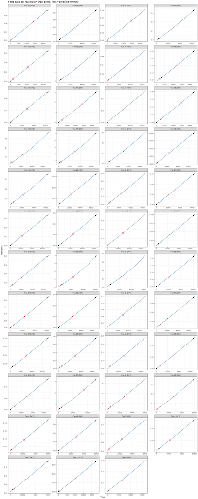

```r
ggplot() +
  geom_line(data = curve_points, aes(x = x, y = y), color = "steelblue", linewidth = 0.7) +
  geom_point(data = input_points, aes(x = x, y = y), color = "black", size = 1.8) +
  geom_point(data = predicted_points, aes(x = x, y = y), color = "red", shape = 4, stroke = 1, size = 2) +
  facet_wrap(~ panel_id, scales = "free", ncol = 4) +
  labs(x = "Time", y = "Rate (abs)",
       title = "Fitted curve per row (black = input points, red x = predicted rmr/mmr)") +
  theme_bw(base_size = 10) +
  theme(strip.text = element_text(size = 8))
```

## Write output CSV

```r
write_csv(results, "../GENERATED_DATA/calculated_background_curve.csv")
```